# DATA VORTEX A'26 — Round 3 Analysis Notebook

**Topic:** Public Reaction to a Viral Product Launch  
**Data Source:** Bluesky Social  
**Analysis Date:** 2026-09-22

This notebook reproduces the Round 3 workflow. All results are loaded from the final output CSVs produced by the pipeline scripts. The frozen Round 2 model was not retrained or modified.

**Final dataset stats:**

- Original collected posts: 1,320
- Relevant posts (after topic-relevance filtering): **587**
- Sentiment shifts detected: **10**
- Engagement spikes detected: **1**
- Total flagged events: **11**
- Trigger evidence: 0 Strong / 1 Weak / 10 Unexplained

## 0. Setup

```
R3: C:\Users\dhrit\Downloads\datavortex\Round3
Exists: True
```

## 1. Data Collection

Data was collected from Bluesky Social via `Round3/src/01_collect_bluesky.py`.

- Authenticated via `bsky.social` (credentials in `Round3/.env`, not tracked by git)
- **Single-shot collection** — one API run on 2026-09-22
- Queries: `Apple iPhone`, `iphone`, `technology`
- Deduplication by post URI

**Fix 1 (relevance filtering):** 733 off-topic posts removed. Original raw data preserved unchanged.

```
Original posts collected : 1320
Posts after relevance filter: 587
Excluded posts           : 733

Query term distribution (original):
query_term
Apple iPhone    499
technology      496
iphone          325
Name: count, dtype: int64
```

## 2. Preprocessing & Sentiment Inference

The exact Round 2 `clean_text()` function and frozen TF-IDF + LinearSVC model were applied via `Round3/src/02_process_and_predict.py`. No retraining occurred.

- **Round 2 Val Macro-F1:** 60.11%
- **Round 2 Test Macro-F1:** 60.93%
- Classes: Negative, Neutral, Positive
- `future_dated_anomaly` flag added for posts where `created_at > collected_at`

```
Enriched posts: 587
Future-dated anomalies: 6

Sentiment distribution:
sentiment_label
Neutral     213
Positive    208
Negative    166
Name: count, dtype: int64

sentiment_label
Neutral     36.3%
Positive    35.4%
Negative    28.3%
Name: proportion, dtype: object
```

## 3. Timeline Construction

Built by `Round3/src/03_build_timeline.py`.

- 22 hourly UTC buckets
- Engagement = likes + reposts + replies + quotes per bucket
- Original `created_at` timestamps preserved unaltered (6 future-dated anomalies included)

```
Hourly buckets: 22
Total engagement across all buckets: 753
```

[output not shown]

## 4. Event Detection

Built by `Round3/src/04_detect_events.py`.

**Fix 2:** Engagement spike detection corrected to use `total_engagement` (likes+reposts+replies+quotes), not post count.

- Sentiment shift threshold: ≥15 pp change in polarity (`pct_positive − pct_negative`)
- Engagement spike threshold: `mean_engagement + 2σ` = **115.21 engagement units**
- All 22 buckets scanned

```
Total flagged events: 11
Sentiment shifts:     10
Engagement spikes:    1
```

[output not shown]

## 5. Figure 1 — Sentiment & Activity Timeline

Generated by `Round3/src/07_build_report_figures.py`.

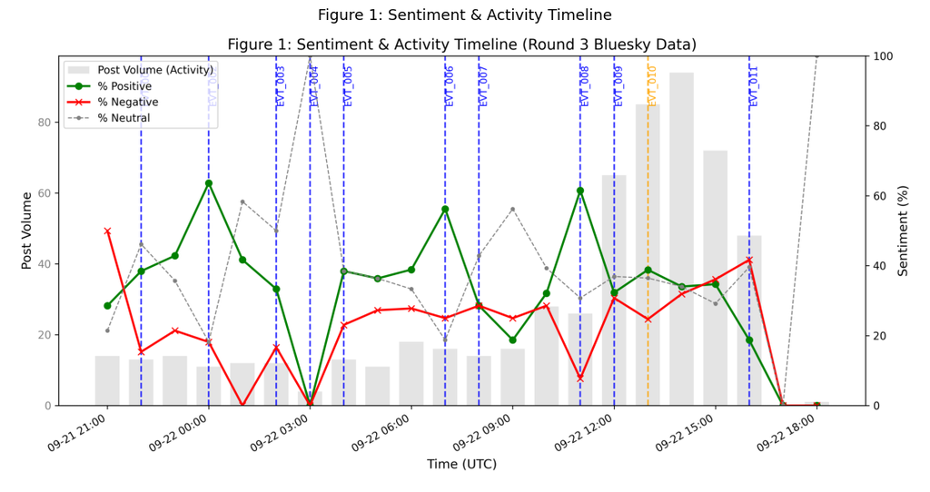

## 6. Topic & Entity Analysis

Built by `Round3/src/05_topic_entity_analysis.py`.

**Fix 3:**

- `<url>` and HTTP artifacts stripped before TF-IDF
- Entity extraction via curated regex dictionary (33 patterns: companies, products, people, platforms)
- All 11 events have genuine entities

```
Events with entities: 11 / 11
```

[output not shown]

## 7. Figure 2 — Event Topic Comparison (EVT_003)

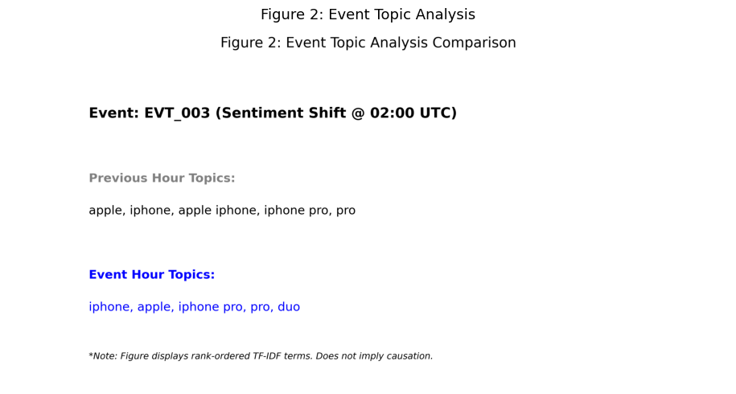

## 8. Trigger Investigation

Built by `Round3/src/06_trigger_lookup.py`.

```
Total candidate articles fetched: 79
Events covered: 9

Final classification: 0 Strong / 1 Weak / 10 Unexplained
Weak: EVT_003 — iPhone 18 teardown video, published ~20h before event
All others: Unexplained (HN API too developer-oriented for consumer news triggers)
```

## 9. Limitations

1. **Single-shot collection** — no continuous monitoring baseline
2. **Bluesky scope** — smaller than Twitter/Reddit
3. **6 future-dated `created_at` anomalies** — cause unknown, preserved unaltered
4. **Frozen Round 2 model** (Macro-F1 ~60%) — English-centric, struggles with cross-language/mixed-entity posts
5. **Entity extraction** — regex dictionary only; NLTK/spaCy unavailable in this environment
6. **10/11 events unexplained** — HackerNews API misses consumer-facing news triggers
7. **~21-hour observation window** — no pre-event baseline